# CPLN 503- A More Formal Introduction to Geoprocessing Tools

October 4 Video Demonstration

Jamaal Green

2023-10-02

# Introduction

We will be covering some of the essential *spatial* tools that make GIS special compared to other analytical approaches (remember, spatial isn’t special…unitl it is). These tools allow us to model different relations in space and often make up the core of a GIS analysis and workflow. We cover many topics in this course, but this week, and the combing weeks, are what will transforms us from analysts who think about space to spatial analysts.

For this walkthrough we’ll be using **sf**, **tmap** , **nngeo** and the **tidyverse** packages. You all should know how to load them up by now, or if you do not have them installed, then how to properly install and load them up.

# The Tools

## Clip

As said in the video, clip is a workhorse tool. Check the [ESRI help page](https://pro.arcgis.com/en/pro-app/latest/tool-reference/analysis/clip.htm) on it for further details.

I read in the layers from the geopackage in order to see what’s available and import the “inside”, “outside” and “farmers_farkets” layers.

```r
geoprocess_layers <- st_layers(here::here("memo/lectures/2023-10-04_Geoprocessing/geoprocessing_tour.gpkg"))

inside <- st_read(dsn = here::here("memo/lectures/2023-10-04_Geoprocessing/geoprocessing_tour.gpkg"), layer = "inside",
                  quiet = TRUE)

outside <- st_read(dsn = here::here("memo/lectures/2023-10-04_Geoprocessing/geoprocessing_tour.gpkg"), layer = "outside",
                   quiet = TRUE)

farmers <- st_read(dsn = here::here("memo/lectures/2023-10-04_Geoprocessing/geoprocessing_tour.gpkg"), layer = "farmers_market", quiet = TRUE)
```

Next, we will calculate the acreage of the “outside” object using the *st_area()* command and convert the square feet to acres using the *set_units()* function from the **units** package (**units** is a base R package). The basic logic of the call here is that I wrapped the *st_area()* call within the *set_units()* call, and set the “value =” argument from *set_units()* to acres. I could have split these into two separate calls, but it is not strictly necessary. Also note that the dataframe for Acres now includes the units within the cell. This may be a nuisance if you want to do further calculations so you can drop the specific unit label by wrapping it in as *as.numeric()* call if need be, but it is not necessary for our purposes here.

```r
outside <- outside %>%
  mutate(Acres = units::set_units(x = st_area(.), value = "acres"))

outside
```

```
## Simple feature collection with 1 feature and 3 fields
## Geometry type: MULTIPOLYGON
## Dimension:     XY
## Bounding box:  xmin: 2667077 ymin: 241516.9 xmax: 2705445 ymax: 276239.1
## Projected CRS: NAD83 / Pennsylvania South (ftUS)
##   SHAPE_Length SHAPE_Area            Acres                           geom
## 1     120122.9  884680746 20309.48 [acres] MULTIPOLYGON (((2694855 273...
```

Now, let’s do the clip. As Prof. O’Neill covers, as does the help file, clip allows us to take a section of an input feature from the shape of a clip feature. Think of it as a cookie cutter, hole puncher etc…so let’s clip our “outside” layer using our “inside” layer in order to get a clipped outside. Note that **sf** does NOT have a “clip” tool, because a clip is a form of an intersect. This is where differences across software can be confusing sometimes. The differences between the two involve whether you want to keep the features from both layers or just the feature you wanted clip. ArcPro separates these two things with the “intersect” and “clip” tools while **sf** uses only the intersect functions available to use (*st_intersection()* and *st_intersects()*). Note, using *st_intersection()* we get attributes from **both** features.

```r
outside_clip <- st_intersection(outside, inside)

tmap_mode(mode = "view")


outside_tmap <- tm_shape(outside) +
  tm_fill(col = "dodgerblue4") +
tm_shape(outside_clip) +
  tm_fill(col = "dodgerblue") +
tm_shape(inside) +
  tm_fill(col = "greenyellow")

outside_tmap %>%
  tmap_leaflet() %>%
  leaflet::addLayersControl(overlayGroups = c("inside", "outside_clip", "outside"), position = "topright")
```

[interactive chart not shown]

Because we are using an intersection we can also use this to pick *point features* that intersect with the “inside” feature. Prof. O’Neill mentions how this mirrors the “Select by Location” tool, and it brings up an important point about what ArcPro, and other desktop GIS programs, do in the use of their geoprocessing tools. These tools *abstract* away the underlying operations. “Select by Location” default behavior is “just” an intersect. What the tool does is offer us multiple spatial relations (intersects, within, contains etc) as well as some distance measures, but the basic command is working from an intersection. What we do in R is that we take the underlying functions and build them up into the tools that ArcPro or QGIS provide for us. For most of our work the desktop is perfectly fine, but for more complex operations we may have to go back to R or python in order to build out the steps ourselves so it is important to understand the underlying algorithms in these tools.

Now, when dealing with points, it is not strictly correct that we are doing a clip. Points have no dimension, we they can’t be clipped like a line or polygon. Instead, when working with points we’re performing a spatial subsetting operation. We’ve already done this before in other environments, but now we’ll re the `[` operator for making spatial subsets. Note the additional “,” and then the `op =` argument. The `op =` argument allows us to set the topological relationship we want to subset on. This is a convenient shorthand available in the **sf** package. Note the magenta colored farmers markets within the “inside” object.

```r
inside_farmers <- farmers[inside, , op = st_within]


farm_subset <- tm_shape(outside) +
  tm_fill(col = "dodgerblue4") +
tm_shape(inside) +
  tm_fill(col = "gray82") +
tm_shape(farmers) +
  tm_dots() +
tm_shape(inside_farmers) +
  tm_dots(col = "magenta1")

farm_subset %>%
  tmap_leaflet() %>%
  leaflet::addLayersControl(overlayGroups = c("farmers","inside_farmers", "inside", "outside"), position = "topright")
```

[interactive chart not shown]

## The Erase Tool

The “erase” tool is a cousin to the clip tool. Instead of keeping the remainder of our polygon from the clip layer (remember like a cookie cutter) we are actually erasing that area. The equivalent for this in **sf** is the *st_difference()* function. Note that after the tool we have a nice new feature with an “inside” shaped hole. Also note that like other tools *st_difference()* brings the attributes of both objects over.

```r
outside_diff <- st_difference(outside, inside)

outside_example <- tm_shape(outside) +
  tm_fill(col = "dodgerblue4") +
tm_shape(inside) +
  tm_fill(col = "gray82") +
tm_shape(outside_diff) +
  tm_fill(col = "black")

outside_example %>%
  tmap_leaflet() %>%
  leaflet::addLayersControl(overlayGroups = c("inside", "outside"), position = "topright",
                            baseGroups = "OpenStreetMap")
```

[interactive chart not shown]

## Intersect

While we’ve covered intersections multiple times already, the specific use case Prof. O’Neill brings up warrants further attention. Careful readers will note when running *st_intersection()* that it takes **one** or **two** objects. In the case from the video we have six layers. How can we handle such a situation? This is a great example of how desktop GIS handles more complicated interactions for us, but understanding the underlying logic allows us more flexiblity, if need be, when working in our own workflows. I introduce a new function here: *bind_rows()*, allows you to stack data frames on top of each other (note this is **NOT** a join). Binding the 6 layers together into a new dataframe, cc_students, with six rows. Now we can run the intersection on our simple features dataframe.

```r
cc_student1 <- st_read(dsn = "Oct_5th_Data/Oct5_DemonstratingTools.gdb", layer = "CC_Student_One")
cc_student2 <- st_read(dsn = "Oct_5th_Data/Oct5_DemonstratingTools.gdb", layer = "CC_Student_Two")
cc_student3 <- st_read(dsn = "Oct_5th_Data/Oct5_DemonstratingTools.gdb", layer = "CC_Student_Three")
cc_student4 <- st_read(dsn = "Oct_5th_Data/Oct5_DemonstratingTools.gdb", layer = "CC_Student_Four")
cc_student5 <- st_read(dsn = "Oct_5th_Data/Oct5_DemonstratingTools.gdb", layer = "CC_Student_Five")
cc_student6 <- st_read(dsn = "Oct_5th_Data/Oct5_DemonstratingTools.gdb", layer = "CC_Student_Six")

cc_students <- bind_rows(cc_student1, cc_student2, cc_student3, cc_student4, cc_student5, cc_student6)

cc_intersection <- st_intersection(cc_students)

head(cc_intersection)
```

[output not shown]

The cc_intersection layer looks much more complicated than what we get from the “intersect” tool in ArcPro. This is a great example of how desktop GIS software such as ArcPro or QGIS do a lot of the complex processing for you with their toolsets.The intersect tool in ArcPro returns a single feature that is the intersection of **all** layers. That is, it returns the intersection of 6 polygons. The *st_intersection()* function, meanwhile, returns *all* intersections of your layers. In this case, with six polygon layers, the possible number of intersections is between 0 and 6. In the default use, *st_intersection()* takes two layers and returns their intersected features. But with more than two layers, *st_intersection()* does not assume to know which set of intersected features you want and so returns all of them. When this occurs, the function outputs some new variables to help you track what’s going on. Of interest to us right now is the `n.overlaps` column. This column tells us the number of overlaps the geometry represents.

In order to get the output that ArcPro returns to us we can use *filter()* function to return the feature with 6 overlaps. But first, let’s actually examine with the cc_intersection layer actually returns to us (I’m going to use base *plot()* here because there are some weird geometry issues with the final dataframe that don’t play nice with **tmap**).

This figure shows *all* of the overlapping features returned from our intersection and is color coded based on the number of overlaps found in the polygon.

All Intersecting CC Features

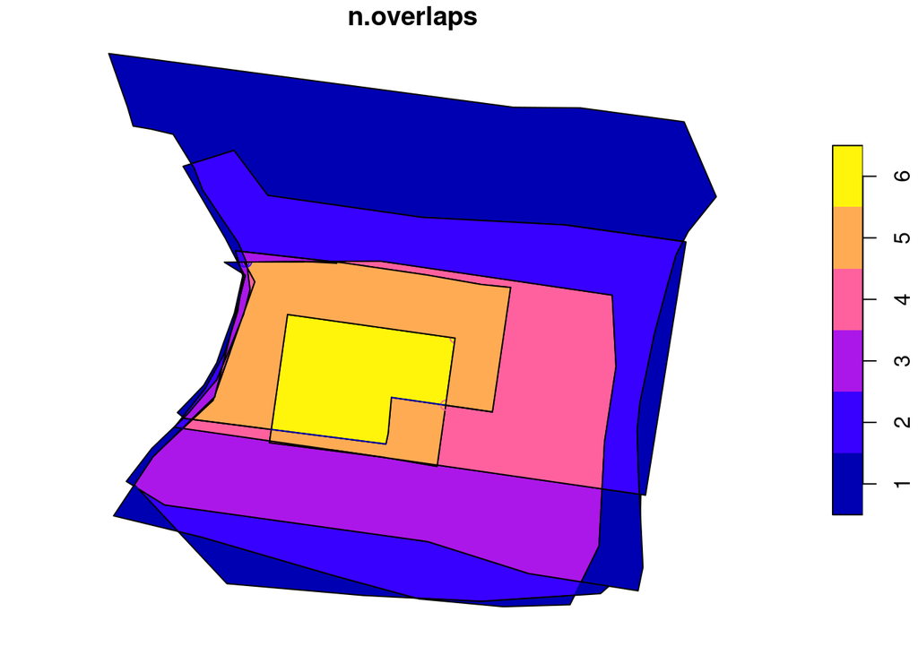

```r
plot(cc_intersection[6])
```

Now, using dplyr, we can pull out our final feature and display that, and behold, it’s the final polygon we get from ArcPro! Now, in most of our workflows this may not be especially important, but, again, it is important to understand the underlying logics of these tools and what they’re abstracting away in case you ever want to do something that isn’t immediately available to you through those particular tool sets.

Final CC Intersection

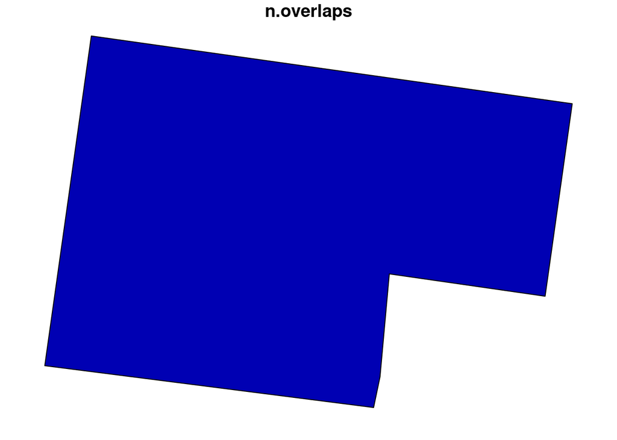

```r
cc_final <- cc_intersection %>%
  filter(n.overlaps == 6)

plot(cc_final[6])
```

## Union

The union tool combines features together. Gnerally, this results in a new single geometry, but we do have options to maintain the original geometries within the union feature if we so choose. This tool has a straightforward cousin in **sf** with the *st_union()* function. The default behavior of the function returns a single feature whereas if you type `by_feature = TRUE` in the *st_union()* call it will return all features. Let’s take a look using our center cc polygons.

Note that in this version with the default behavior we have a single geometry returned

```r
cc_union <- st_union(cc_students)

tmap_mode("view")

cc_union_map1 <- tm_shape(cc_students) +
  tm_fill(col = "NameID") +
tm_shape(cc_union) +
  tm_fill(col = "dodgerblue")

cc_union_map1 %>%
  tmap_leaflet() %>%
  leaflet::addLayersControl(overlayGroups = c("cc_students", "cc_union"), position = "topright")
```

[interactive chart not shown]

CC Union (default)

Say we want to maintain the individual features for our own reference? If that is the desire result, then we would make `by_feature = TRUE`. Let’s take a look. And behold, we have all of our features delineated in our layer. Now, a key difference here is that this tool does not return a column telling us how whether or not a feature has any overlaps like in ArcPro, but what function have we used today that could us answer that question?

```r
cc_union_features <- st_union(cc_students, by_feature = TRUE)

tmap_mode("view")

cc_union_map2 <- tm_shape(cc_students) +
  tm_fill(col = "NameID") +
tm_shape(cc_union_features) +
  tm_fill(col = "NameID", palette = "Pastel2")

cc_union_map2 %>%
  tmap_leaflet() %>%
  leaflet::addLayersControl(overlayGroups = c("cc_students", "cc_union"), position = "topright")
```

[interactive chart not shown]

CC Union By Faeture

## Near Tool

This next section will be more complex because we will be dealing with matrices for some output. While intimidating, they are necessary for these operations in R, and they are also present in ArcPro depending on the tool. We won’t go into immense detail on them (first, I’m not a very good matrix person, and, second, it’s not strictly necessary for the narrow use case we have right here).

The near tool Prof. O’Neill demonstrates returns the *nearest neighbor* of our features of interest. In this case, farmers markets and potential places to live. This is another example where the tool abstracts some of the intermediate steps to our benefit. In order to reproduce this in R there are a couple of approaches. The first is we will use a new package **nngeo**, a purpose built package for calculating nearest neighbor distances at blazing fast speeds.

In our first example, we’ll use **nngeo**. The output from **nngeo** is a list. Four our case, because we are looking for the nearest neighbor, we should be able to take the resulting list and simply append it to our farmers market simple features dataframe with the distances. First, we will bring in the places to live variable from geodatabase and then run the *st_nn()* function. Note that we ask for only a single object to be returned with the `k = 1` command and we also would like the distances to be returned with the `returnDist = TRUE`. Unfortunately, **nngeo** has trouble with “ftUS” units of our current project so we will re-project our layers of interest to a projection it can handle: [NAD83(HARN) Pennsylvania South](https://epsg.io/3364). This will change our units to meters, but we can convert back if need be.

```r
places_to_live <- st_read(dsn = here::here("memo/lectures/2023-10-04_Geoprocessing/geoprocessing_tour.gpkg"),
                          layer = "Places_You_May_Live") %>%
  st_transform(crs = 3364)

farmers_harn <- st_transform(farmers,
                             crs = st_crs(places_to_live))

farmers_dists <- st_nn(x = places_to_live, y = farmers_harn,
                       k = 1, returnDist = TRUE)

places_to_live <- places_to_live %>%
  mutate(dist_m = as.numeric(farmers_dists$dist))

#convert to feet

places_to_live <- places_to_live %>%
  mutate(dist_ft = dist_m * 3.281)
```

| ADDRESS | Distance Meters | Distance Feet |
| --- | --- | --- |
| 103 N YEWDALL ST | 460.8286 | 1511.979 |
| 2127 N CORLIES ST | 391.7850 | 1285.447 |
| 827 MOORE ST | 410.9195 | 1348.227 |
| 433 RIPKA ST | 313.2358 | 1027.727 |
| 5914 LOCUST ST | 1408.6920 | 4621.918 |
| 3328 W ALLEGHENY AVE | 662.7332 | 2174.428 |
| 4420 COMLY ST | 1331.8382 | 4369.761 |
| 4505 TACKAWANNA ST | 1497.9986 | 4914.933 |
| 4718 C ST | 2507.0467 | 8225.620 |

So we transformed our layers to a projection that **nngeo** was more comfortable with. The resulting object, farmers_dist, is a list with two elements “nn” and “dist”. “nn” is its own list and it has the row indices of the nearest farmers market. That is if we got to our farmers market table and go to the rows that match those indices we can identify which market is the closest. Second, “dist” is a list of the distances to the nearest features. Because the lists correspond to the rows in our places_to_live_harn dataframe we can slap them directly onto our dataframe. This is because nngeo *preserves the order*. I generally am terrified of this because it requires placing trust in the order being maintained, but we can see it lines up well here. Note I used the `$` operator to go into the list and pull out the main elements with it. This is also the base R way of grabbing columns from our dataframes! Because, remember, a dataframe is a special form of list!

This case is by far the most straightforward option for most of us which gets to an issue with R. I hope to demonstrate that R can be an excellent complement to our GIS work, but there are some tools or approaches that are just easier to do in desktop GIS platforms. Distance measures are one of those things. Packages like **nngeo** make this much easier to deal with as we deal with lists and not super dense, naked distance matrices, but this is hard to beat compared to ArcPro’s near tool. I would still encourage you all to experiment with this package and get comfortable as the underlying code is written in C, an incredibly fast low level language and can allow for meatier distance calls than may be possible in ArcPro depending upon your hardware.

In the interest of time I won’t go over the *st_distance()* workflow from **sf**. Not because it doesn’t work, but because I want to respect our time and space and not deal with distance matrices just yet. If curious, we will cover this more in the coming weeks.

## Buffer

We’ve already seen the buffer in action so I won’t belabor it here. Look at the videos and really look at the different ways one can play with the tool.

# Conclusion

These are some of the essential geometric operations that make up the bulk of many GIS analyses. As Prof. O’Neill’s videos show, they are incredibly versatile and allow us to map “what isn’t quite there”. This is, arguably, one of the purest essences of GIS. This walkthrough was to show how we can do much of the geoprocessing we see here in R. Remember, there isn’t one way to do these things, but I want to demonstrate that we can use as a fairly robust GIS on its own, and for us to think about ways R can be a useful complement to our work in ArcPro or in some other workflows.

I want to reiterate what I mentioned earlier about desktop GIS and abstracting away certain steps. The tools provided by desktop GIS applications are *incredibly* powerful and useful and serve us well in the vast majority of our work. That being said, there will be times when we have a particular workflow that requires us to use the tools in slightly different ways than they are intended. It is possible to stretch these tools quite a bit, but sometimes we need to get lower level. Note that we can do a lot of what was demonstrated in the video using the simple function **sf** gives us. By chaining those tools together we can build up incredibly complex spatial operations that may not be easily doable using the tools presented to us on desktop.